# Turner Syndrome (X0/XX/XY/XXY) — RNA-seq analysis (GSE126712)

# Overview

Turner syndrome (X0) RNA-seq analysis using **GSE126712** — peripheral blood lymphocytes from a four-karyotype cohort (X0, XX, XY, XXY) generated by the Skuse / Raznahan groups. Counts are RSEM `expected_count` tables deposited at GEO; phenotype metadata is fetched live via `GEOquery`.

Three contrasts are run from a single voom fit:

| Contrast | Coef | Question |
| --- | --- | --- |
| `XO − XY` | group | Turner monosomy vs. normal male — primary contrast (matches mature MSY-lost LOY in somatic cells) |
| `XO − XX` | group | Turner monosomy vs. normal female — secondary contrast (isolates the lost X copy with the normal X background) |
| `dose` | linear | X-chromosome dosage gradient (1/2/3 ≡ X0/XX-XY/XXY) — picks out X-dosage-responsive genes regardless of sex |

The dosage model is **Turner-specific** and replaces the cell-line-specific §8 module that AR / PI3K occupies in the LNCaP base notebook.

Every figure is saved to `figures_X0_vs_XY/` as both PNG (for iterative review) and PDF (for publication).

**Counts pipeline.** GSE126712 distributes RSEM gene-level tables (`*.genes.results.txt.gz`), one per sample. Gene IDs are concatenated `ENSGxxxx.v_SYMBOL`. Y-chromosome (MSY) genes are stripped from the DGEList because X0 samples lack them entirely and would dominate every contrast; PAR genes are preserved at the DE level and filtered out only at pathway-analysis boundaries (matching the canonical policy in `analysis/02_rnaseq/2.3.1_rnaseq_LNCaP_base.Rmd`).

| Karyotype | n | X dose | Y dose | Role |
| --- | --- | --- | --- | --- |
| XO | varies | 1 | 0 | Turner monosomy (primary) |
| XX | varies | 2 | 0 | Normal female (secondary reference) |
| XY | varies | 1 | 1 | Normal male (primary reference) |
| XXY | varies | 2 | 1 | Klinefelter trisomy |

# 1. Setup

## 1.1 Load Packages

## 1.2 Paths, Parameters, and PNG-First Figure Helper

## 1.3 Color Palette (Okabe-Ito)

# 2. Data Loading

## 2.1 Load RSEM Count Data

```
## Found 54 RSEM gene result files
```

```
## Count matrix: 60498 genes x 54 samples
```

## 2.2 Fetch Phenotype Data from GEO

GSE126712 Sample Summary

| karyotype | n |
| --- | --- |
| XO | 13 |
| XX | 14 |
| XY | 13 |
| XXY | 14 |

## 2.3 Parse Gene Annotations

```
## Removing 50 ENSGR (chrY-PAR duplicate) entries
```

```
## Genes after ENSGR filter: 60448
```

## 2.4 Create DGEList Object

```
## DGEList: 60448 genes x 54 samples
```

# 3. QC: Filter, TMM

## 3.1 Library Sizes

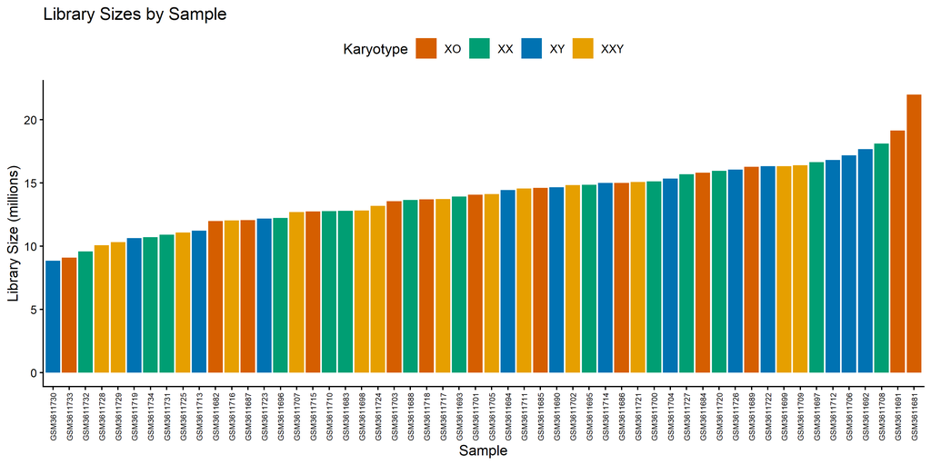

```
## Saved: library_sizes.(png|pdf)  [10x5 in]
```

## 3.2 Filter Lowly Expressed Genes

```
## Before filtering: 60448
```

```
## After filtering:  15812
```

## 3.3 TMM Normalization

First 10 samples — library sizes and norm factors

| sample | karyotype | lib.size | norm.factors | lib.size_M |
| --- | --- | --- | --- | --- |
| GSM3611681 | XO | 21948746 | 1.0452724 | 21.9 |
| GSM3611682 | XO | 11949646 | 1.0731966 | 11.9 |
| GSM3611683 | XX | 12764009 | 1.0274968 | 12.8 |
| GSM3611684 | XO | 15783132 | 1.0526535 | 15.8 |
| GSM3611685 | XO | 14595481 | 1.0141906 | 14.6 |
| GSM3611686 | XO | 14986975 | 0.9549958 | 15.0 |
| GSM3611687 | XO | 12028784 | 0.9823384 | 12.0 |
| GSM3611688 | XX | 13620720 | 0.9797761 | 13.6 |
| GSM3611689 | XO | 16255039 | 0.9714412 | 16.3 |
| GSM3611690 | XY | 14633524 | 1.0486574 | 14.6 |

## 3.4 Density Plots (Pre vs Post Normalization)

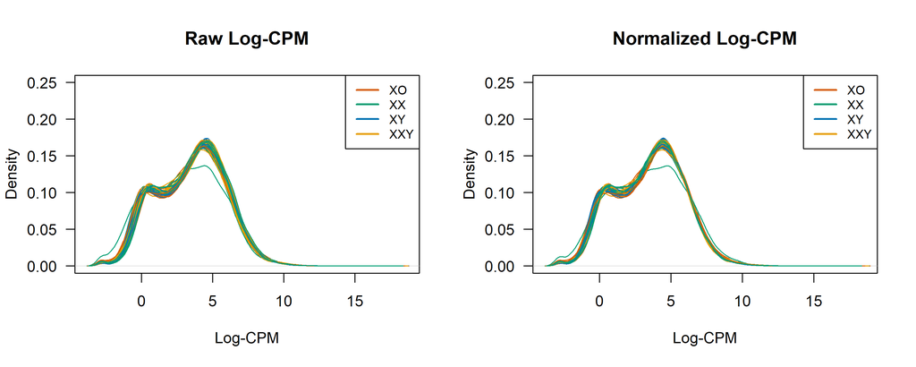

## 3.5 MDS / PCA

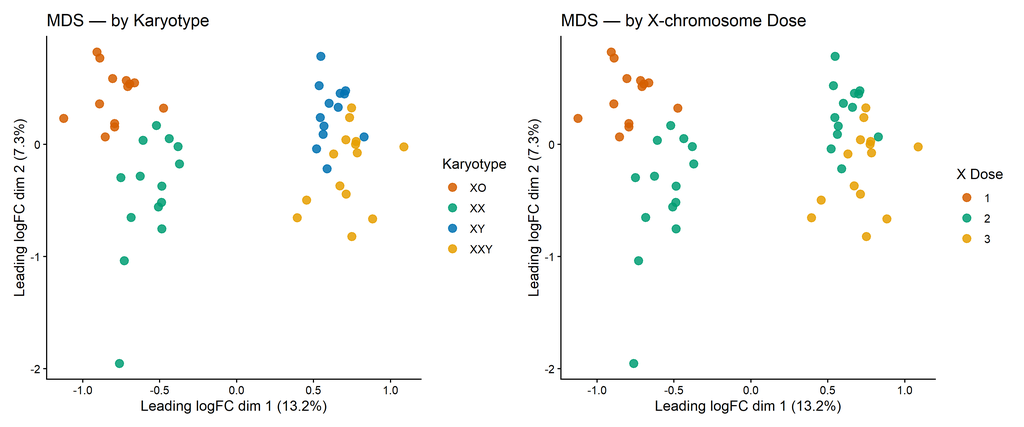

```
## Saved: mds_karyotype_dose.(png|pdf)  [12x5 in]
```

## 3.6 Sample Distance Heatmap

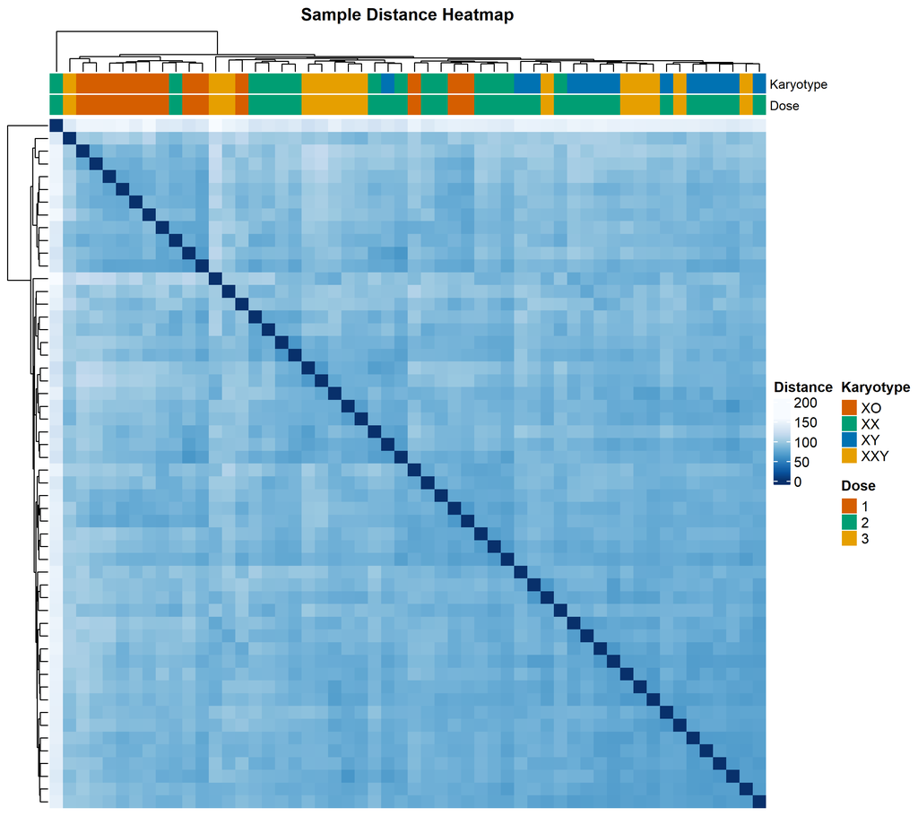

# 4. Y Chromosome / PAR Handling

Sanity check: X0 samples lack chrY entirely, so MSY expression should be at floor in X0 (and similarly in XX). XY and XXY should carry MSY signal. PAR genes (chrX/chrY shared) should track with X-chromosome dose.

The same canonical filter policy applies as in the LNCaP base notebook:

- **DE flow:** MSY (chrY) is stripped from the DGEList before voom; **PAR genes are retained** so they get logFC + FDR values in `topTable`.
- **Pathway flow (fgsea / decoupleR ULM / DoRothEA / GSVA):** both MSY and PAR genes are stripped at the rank-vector / matrix input boundary inside `prep_ranks_t()` and the equivalent matrix builds — PAR signal in those ranks is library-composition artefact (X0 samples lose one PAR copy with their lost X), not pathway biology.

## 4.1 Y-region annotation

```
## MSY genes (in data, to be stripped from DGE):  17
```

```
## PAR genes (in data, preserved at DE; stripped at pathway): 18
```

```
##   PAR retained:  CSF2RA, IL3RA, SLC25A6, ASMTL, P2RY8, AKAP17A, DHRSX, ZBED1, CD99, ARSD, PRKX, GTPBP6, PPP2R3B, PLCXD1, SPRY3, VAMP7, IL9R, WASH6P
```

## 4.2 Strip MSY from DGE, keep PAR

```
## Genes after MSY removal: 15795
```

```
## Genes after Entrez filter: 13168
```

## 4.3 PAR Gene Expression by Karyotype

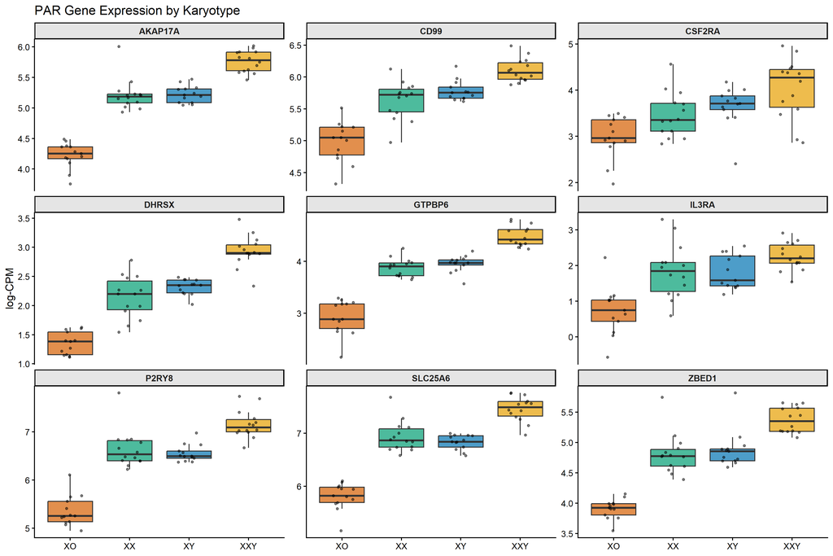

```
## Saved: par_genes_boxplot.(png|pdf)  [12x8 in]
```

# 5. Differential Expression

## 5.1 Helper functions (ranks, fgsea, enrichment, regulon volcano)

All helpers used by GSEA (§7-§9), TF (§10-§11), and cross-method (§12) are defined here in one place so they’re available everywhere downstream. The key adaptation vs. the existing exploratory turner Rmd: `prep_ranks_t()` now strips **chrY ∪ PAR ∪ RPS/RPL** at the rank boundary, matching the canonical LNCaP / A549 / HT1080 pathway-input policy.

## 5.2 Design matrices

```
## Group design:
```

```
##            XO XX XY XXY
## GSM3611681  1  0  0   0
## GSM3611682  1  0  0   0
## GSM3611683  0  1  0   0
## GSM3611684  1  0  0   0
## GSM3611685  1  0  0   0
## GSM3611686  1  0  0   0
```

```
##
## Dose design:
```

```
##            Intercept Dose
## GSM3611681         1    1
## GSM3611682         1    1
## GSM3611683         1    2
## GSM3611684         1    1
## GSM3611685         1    1
## GSM3611686         1    1
```

## 5.3 Estimate dispersion + voom

```
## Common dispersion: 0.0634   BCV: 0.252
```

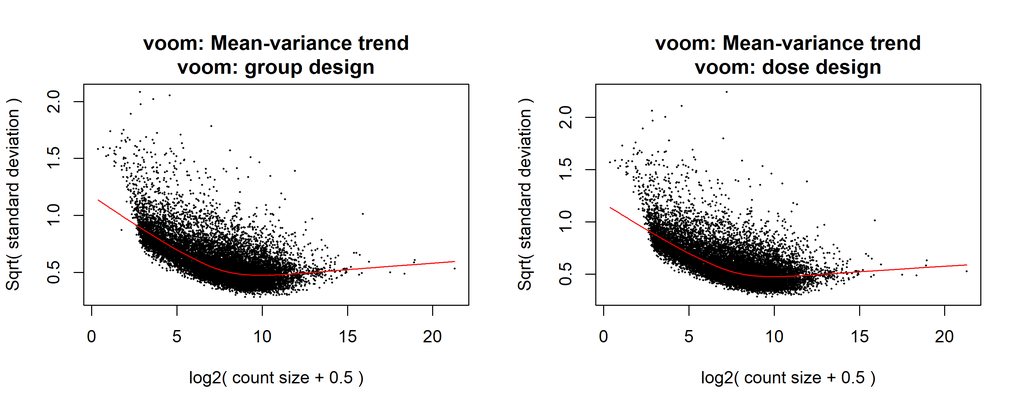

## 5.4 Primary contrast: X0 vs XY

```
## === X0 vs XY ===
```

```
##        XO_vs_XY
## Down        307
## NotSig    12564
## Up          297
```

```
##
## Top up in X0:
```

```
##                             gene_symbol     logFC    adj.P.Val
## ENSG00000257599.1_OVCH1-AS1   OVCH1-AS1 3.2699510 3.997366e-07
## ENSG00000228223.2_HCG11           HCG11 0.6473036 1.726784e-06
## ENSG00000100320.22_RBFOX2        RBFOX2 1.5901392 4.539142e-06
## ENSG00000115129.13_TP53I3        TP53I3 1.0520912 1.134702e-05
## ENSG00000077585.13_GPR137B      GPR137B 0.8383906 2.347615e-05
## ENSG00000244274.7_DBNDD2         DBNDD2 0.6157371 7.413550e-05
## ENSG00000152556.15_PFKM            PFKM 0.5004570 1.407256e-04
## ENSG00000134755.14_DSC2            DSC2 1.4767162 1.421402e-04
## ENSG00000110799.13_VWF              VWF 1.3673640 1.465893e-04
## ENSG00000101335.9_MYL9             MYL9 1.6680033 1.478185e-04
```

```
##
## Top down in X0:
```

```
##                            gene_symbol      logFC    adj.P.Val
## ENSG00000197976.10_AKAP17A     AKAP17A -1.0102128 3.300847e-13
## ENSG00000178605.12_GTPBP6       GTPBP6 -1.0713846 6.116117e-12
## ENSG00000169100.12_SLC25A6     SLC25A6 -1.0212996 6.116117e-12
## ENSG00000169093.14_ASMTL         ASMTL -0.9480048 2.476692e-11
## ENSG00000182162.9_P2RY8          P2RY8 -1.1993999 1.202143e-10
## ENSG00000214717.9_ZBED1          ZBED1 -0.9807966 2.115213e-09
## ENSG00000169084.12_DHRSX         DHRSX -1.0086583 3.004363e-08
## ENSG00000002586.17_CD99           CD99 -0.8068107 4.683777e-08
## ENSG00000167393.16_PPP2R3B     PPP2R3B -1.0700273 5.822499e-07
## ENSG00000157077.14_ZFYVE9       ZFYVE9 -1.3849966 1.876085e-06
```

### All X0 vs XY DEGs (paginated, FDR < 0.05)

| gene_symbol | ensembl_id | logFC | AveExpr | t | P.Value | adj.P.Val | B |
| --- | --- | --- | --- | --- | --- | --- | --- |
| AKAP17A | ENSG00000197976 | -1.010212766822856 | 5.113051265317806 | -12.32401839267806 | 2.506718201806317e-17 | 3.300846528138557e-13 | 28.9512207875657 |
| GTPBP6 | ENSG00000178605 | -1.071384591860898 | 3.807991608786721 | -11.2219066122519 | 9.784977638262998e-16 | 6.116116565189364e-12 | 25.16443450467034 |
| SLC25A6 | ENSG00000169100 | -1.02129957596947 | 6.772738587872035 | -11.11798317093657 | 1.393404442251526e-15 | 6.116116565189364e-12 | 25.16411275185201 |
| ASMTL | ENSG00000169093 | -0.9480047844255988 | 3.121228879554799 | -10.62752904728093 | 7.523367222538152e-15 | 2.47669248965956e-11 | 22.95961600825443 |
| P2RY8 | ENSG00000182162 | -1.199399917283979 | 6.442505439785266 | -10.11220935020051 | 4.564637718156712e-14 | 1.202142989453752e-10 | 21.78120708040816 |
| ZBED1 | ENSG00000214717 | -0.9807966259242313 | 4.748700827447448 | -9.259098861719249 | 9.637969037668127e-13 | 2.115212938133565e-09 | 18.786357392193 |
| DHRSX | ENSG00000169084 | -1.008658300180756 | 2.159359870436926 | -8.490659105097855 | 1.597094775845031e-11 | 3.004363429761052e-08 | 15.47893776814911 |
| CD99 | ENSG00000002586 | -0.8068106687001695 | 5.631051310433753 | -8.33416553115089 | 2.845550752804809e-11 | 4.683776539116716e-08 | 15.5248296407898 |
| OVCH1-AS1 | ENSG00000257599 | 3.269951047105844 | -1.579527496069051 | 7.725111441615915 | 2.732100193028455e-10 | 3.997366149088744e-07 | 10.93185784314751 |
| PPP2R3B | ENSG00000167393 | -1.070027264123105 | 2.010082398953645 | -7.596067119203568 | 4.4217033284277e-10 | 5.822498942873596e-07 | 12.40601664937264 |

[output cut: 594 more lines]

## 5.5 Secondary contrast: X0 vs XX

```
## === X0 vs XX ===
```

```
##        XO_vs_XX
## Down        723
## NotSig    11691
## Up          754
```

## 5.6 Linear dose-response

```
## === Dose-response (positive = increases with X copy number) ===
```

```
##        Intercept  Dose
## Down         406  1150
## NotSig      1138 11069
## Up         11624   949
```

```
##
## Top dose-positive:
```

```
##                            gene_symbol     logFC    adj.P.Val
## ENSG00000169093.14_ASMTL         ASMTL 0.7400513 5.210746e-20
## ENSG00000197976.10_AKAP17A     AKAP17A 0.7556088 5.620647e-20
## ENSG00000169100.12_SLC25A6     SLC25A6 0.8238318 4.633949e-19
## ENSG00000178605.12_GTPBP6       GTPBP6 0.7647275 1.345555e-18
## ENSG00000169084.12_DHRSX         DHRSX 0.7940163 3.205450e-17
## ENSG00000214717.9_ZBED1          ZBED1 0.7206010 4.363200e-16
## ENSG00000182162.9_P2RY8          P2RY8 0.8963233 4.363200e-16
## ENSG00000167393.16_PPP2R3B     PPP2R3B 0.8214178 4.149086e-15
## ENSG00000157077.14_ZFYVE9       ZFYVE9 0.9989947 1.056091e-13
## ENSG00000132128.16_LRRC41       LRRC41 0.2652947 2.186633e-13
```

```
##
## Top dose-negative:
```

```
##                             gene_symbol      logFC    adj.P.Val
## ENSG00000228223.2_HCG11           HCG11 -0.7735131 1.345555e-18
## ENSG00000257599.1_OVCH1-AS1   OVCH1-AS1 -2.8543302 2.346630e-15
## ENSG00000100320.22_RBFOX2        RBFOX2 -1.2747658 7.620692e-11
## ENSG00000115129.13_TP53I3        TP53I3 -0.7962543 1.156332e-09
## ENSG00000101335.9_MYL9             MYL9 -1.4127999 2.173059e-09
## ENSG00000234465.10_PINLYP        PINLYP -1.1231752 5.455050e-09
## ENSG00000008300.14_CELSR3        CELSR3 -0.7490119 2.007408e-08
## ENSG00000196914.8_ARHGEF12     ARHGEF12 -0.4520434 2.007408e-08
## ENSG00000108239.8_TBC1D12       TBC1D12 -0.5976083 6.009958e-08
## ENSG00000169855.19_ROBO1          ROBO1 -0.9749935 6.322169e-08
```

### All dose-response DEGs (paginated, FDR < 0.05)

| gene_symbol | ensembl_id | logFC | AveExpr | t | P.Value | adj.P.Val | B |
| --- | --- | --- | --- | --- | --- | --- | --- |
| ASMTL | ENSG00000169093 | 0.7400512649170334 | 3.121228879554799 | 17.29875202277298 | 3.957128019576234e-24 | 5.210746176177985e-20 | 44.16587275303822 |
| AKAP17A | ENSG00000197976 | 0.755608802564982 | 5.113051265317806 | 17.0192434289727 | 8.536826511651398e-24 | 5.62064657527128e-20 | 43.83736233701619 |
| SLC25A6 | ENSG00000169100 | 0.8238317520345133 | 6.772738587872035 | 16.12629694989221 | 1.055729548934413e-22 | 4.633948900122784e-19 | 41.39969407641514 |
| GTPBP6 | ENSG00000178605 | 0.7647274591918289 | 3.807991608786721 | 15.58680177838195 | 5.04469973563776e-22 | 1.345554703492176e-18 | 39.72069263429607 |
| HCG11 | ENSG00000228223 | -0.7735130507150156 | 3.166838868989945 | -15.5824687186451 | 5.109184019942951e-22 | 1.345554703492176e-18 | 39.55181294862446 |
| DHRSX | ENSG00000169084 | 0.7940162655434231 | 2.159359870436926 | 14.46452054045803 | 1.460563552327728e-20 | 3.20545014284192e-17 | 35.93416856865966 |
| ZBED1 | ENSG00000214717 | 0.7206009961300955 | 4.748700827447448 | 13.54108806239682 | 2.618833174531467e-19 | 4.363200418873439e-16 | 33.684215999482 |
| P2RY8 | ENSG00000182162 | 0.8963232615983939 | 6.442505439785266 | 13.53727940209199 | 2.65079004791825e-19 | 4.363200418873439e-16 | 33.6804028062884 |
| OVCH1-AS1 | ENSG00000257599 | -2.854330200460823 | -1.579527496069051 | -12.97832412464853 | 1.603863258869012e-18 | 2.346630154754128e-15 | 28.3839689457835 |
| PPP2R3B | ENSG00000167393 | 0.8214178274397336 | 2.010082398953645 | 12.771799260197 | 3.150885529701899e-18 | 4.14908606551146e-15 | 30.807705693586 |

[output cut: 2089 more lines]

# 6. DE Visualization

## 6.1 Volcano — X0 vs XY

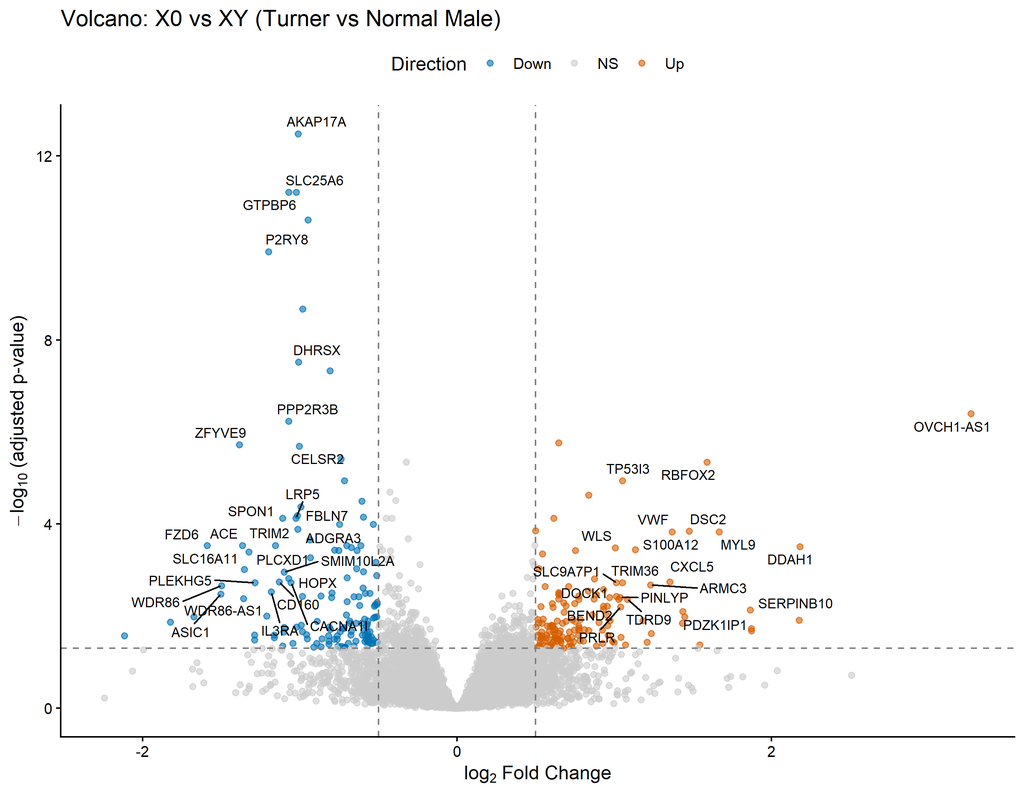

```
## Saved: volcano_X0_vs_XY.(png|pdf)  [9x7 in]
```

## 6.2 MA plot — X0 vs XY

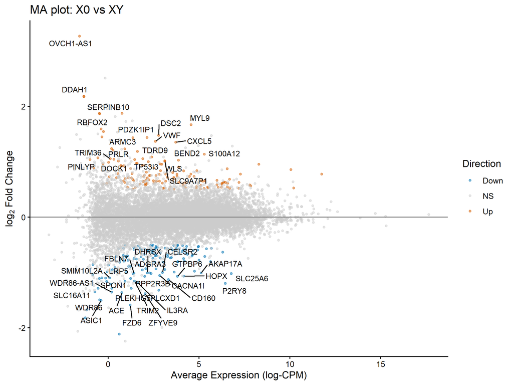

```
## Saved: ma_plot_X0_vs_XY.(png|pdf)  [8x6 in]
```

## 6.3 Top-50 DE Gene Heatmap

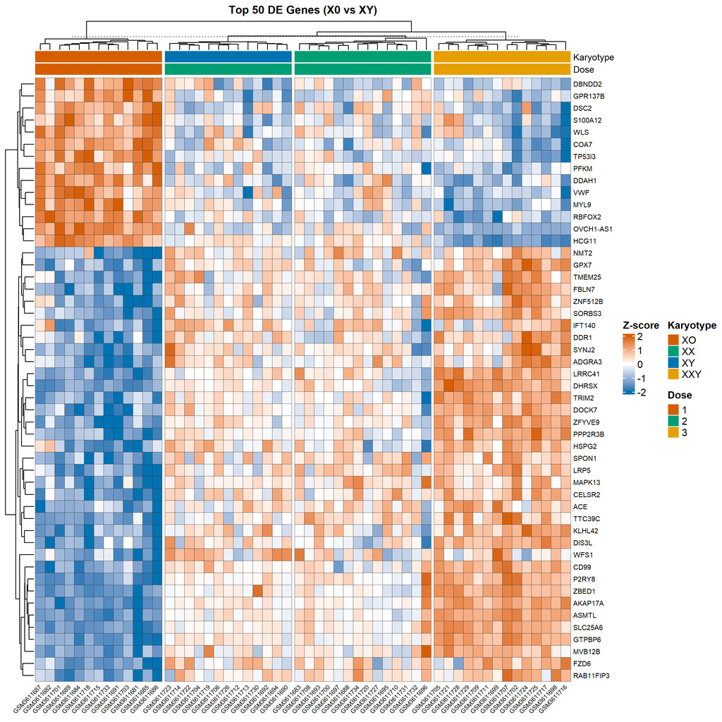

# 7. GSEA (Basic Collections)

## 7.1 Load gene-set collections

```
##   hallmark: 50 gene sets
##   reactome: 1787 gene sets
##   kegg: 186 gene sets
##   go_bp: 7583 gene sets
```

## 7.2 Build ranks — X0 vs XY

```
## Ranked list (X0 vs XY): 13000 genes  [range -7.23 .. 7.73]
```

## 7.3 Run fgsea

```
##   fgsea: hallmark  (50 sets)
```

```
##   fgsea: reactome  (1787 sets)
```

```
##   fgsea: kegg  (186 sets)
```

```
##   fgsea: go_bp  (7583 sets)
```

## 7.4 Summary

X0 vs XY GSEA — significant pathways by collection

| collection | total | sig_up | sig_down |
| --- | --- | --- | --- |
| go_bp | 3401 | 269 | 74 |
| hallmark | 50 | 25 | 7 |
| kegg | 160 | 14 | 4 |
| reactome | 950 | 124 | 53 |

## 7.5 Hallmark dotplot

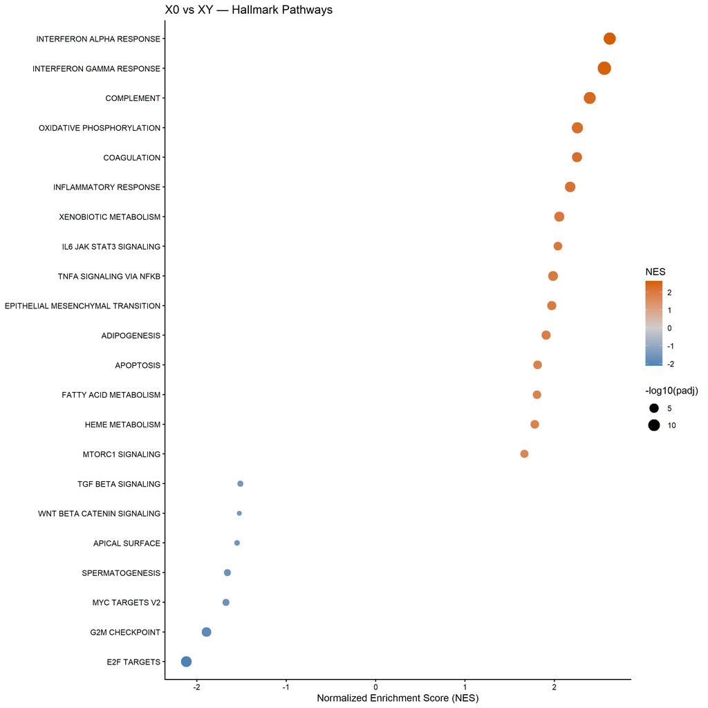

```
## Saved: gsea_dotplot_hallmark.(png|pdf)  [10x10 in]
```

## 7.6 Publication dotplot (top 15 each direction, all collections)

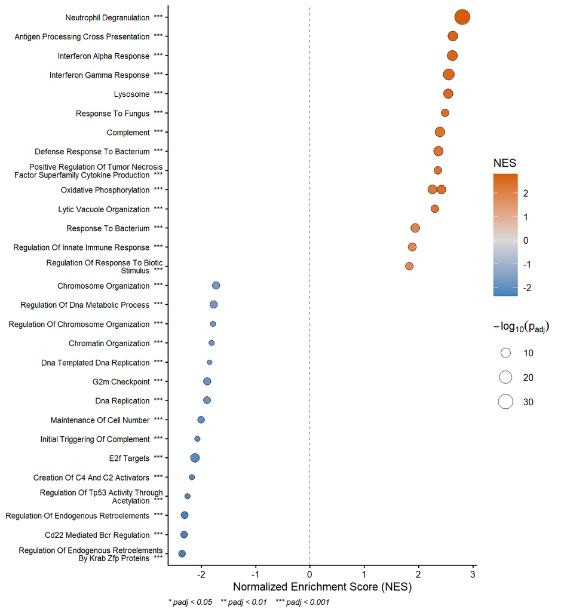

```
## Saved: gsea_dotplot_publication.(png|pdf)  [5.5x6 in]
```

## 7.7 Top Hallmark enrichment curves

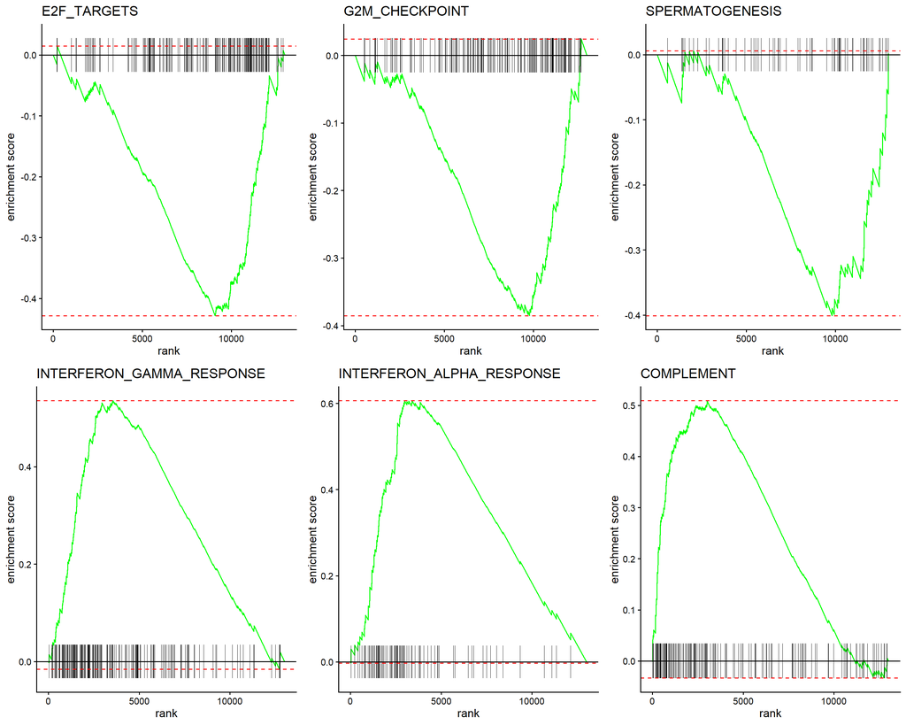

# 8. GSEA (Expanded: CGP + PRC2 / Histone Deep Dive)

The expanded collections (Chemical & Genetic Perturbations, plus a curated histone-modification subset) are the workhorse for the Turner-specific hypothesis that loss of one X dose results in spread of repressive H3K27me3 / loss of bivalent H3K4me3 activating marks at PRC2 targets.

## 8.1 Load CGP + build histone subset

```
## CGP gene sets loaded: 3538
```

```
## Histone-modification CGP sets: 85
```

## 8.2 CGP dotplot

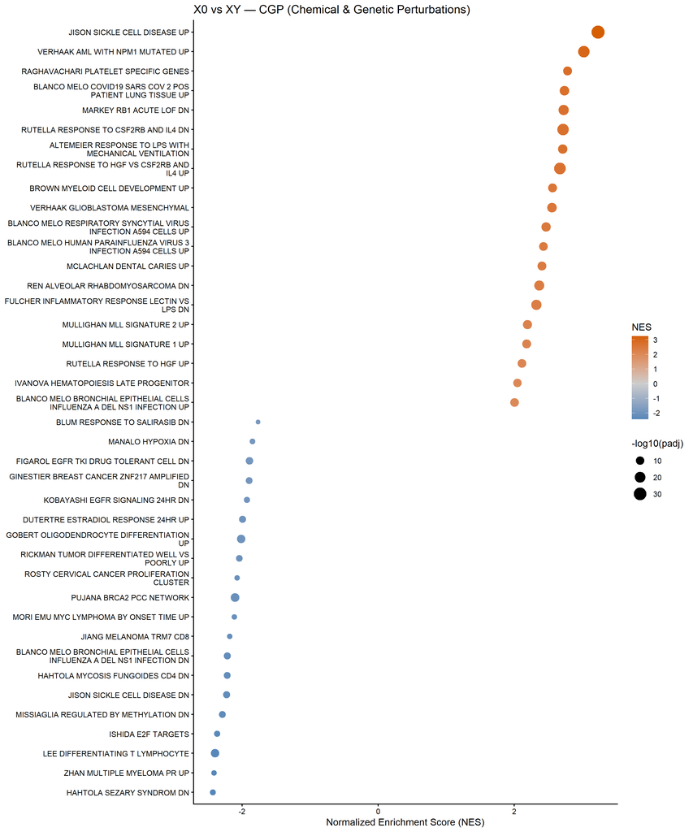

```
## Saved: gsea_dotplot_cgp.(png|pdf)  [10x12 in]
```

## 8.3 PRC2 / H3K27me3 — publication enrichment curves

fGSEA: PRC2 Targets & H3K27me3 (X0 vs XY)

| pathway | NES | pval | padj | size |
| --- | --- | --- | --- | --- |
| BENPORATH_PRC2_TARGETS | 1.0532 | 0.3375 | 0.3375 | 198 |
| MIKKELSEN_MEF_HCP_WITH_H3K27ME3 | -1.0952 | 0.2386 | 0.3375 | 143 |

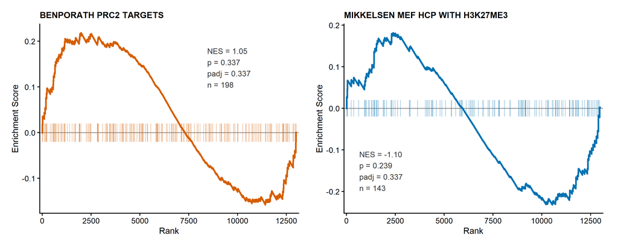

```
## Saved: enrichment_PRC2_H3K27me3.(png|pdf)  [10x4 in]
```

## 8.4 Histone-modification bar plot

```
## Histone CGP sets tested: 70   significant: 16
```

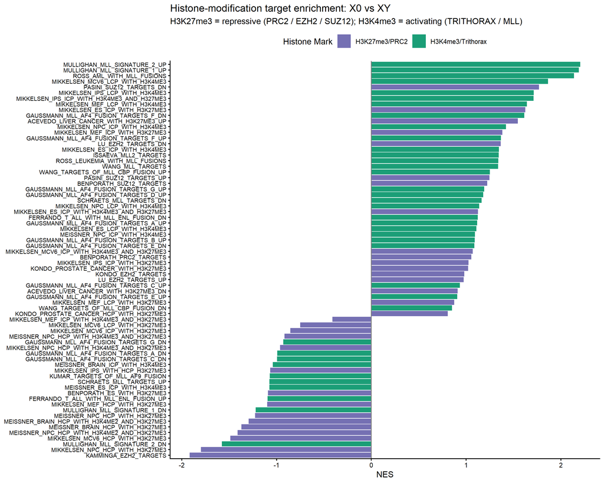

```
## Saved: histone_pathway_enrichment.(png|pdf)  [10x8 in]
```

## 8.5 Top-3 overall publication enrichment

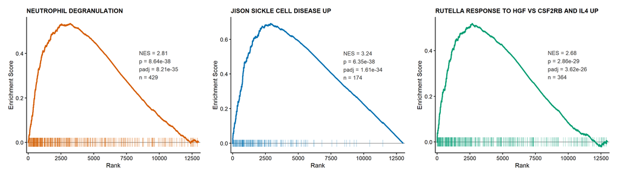

```
## Saved: enrichment_top3_X0_vs_XY.(png|pdf)  [14x4 in]
```

# 9. Sex-Chromosome Dosage GSEA

This is the Turner-specific module replacing the LNCaP §8 AR/PI3K block. The dose coefficient (1=X0, 2=XX or XY, 3=XXY) ranks genes by linear X-chromosome-copy responsiveness regardless of sex; significant pathways here implicate biology that scales with X dose rather than with karyotype identity per se.

## 9.1 Dose-response ranks

```
## Dose-response ranked list: 13000 genes  [range -15.58 .. 11.78]
```

```
## (positive = increases with X chromosome dose)
```

## 9.2 Run fgsea (all collections)

```
##   fgsea: hallmark  (50 sets)
```

```
##   fgsea: reactome  (1787 sets)
```

```
##   fgsea: kegg  (186 sets)
```

```
##   fgsea: go_bp  (7583 sets)
```

```
##   fgsea: cgp  (3538 sets)
```

```
##   fgsea: cgp  (3538 sets)
```

Dose-Response GSEA — significant pathways by collection

[output not shown]

## 9.3 Hallmark + CGP dose dotplots

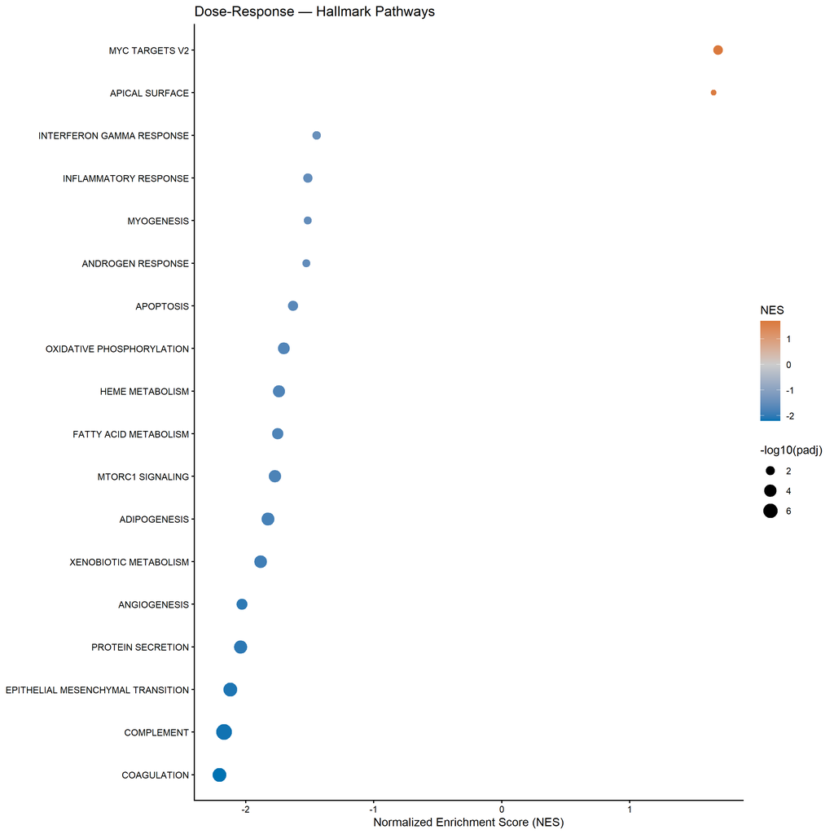

```
## Saved: dose_gsea_hallmark.(png|pdf)  [10x10 in]
```

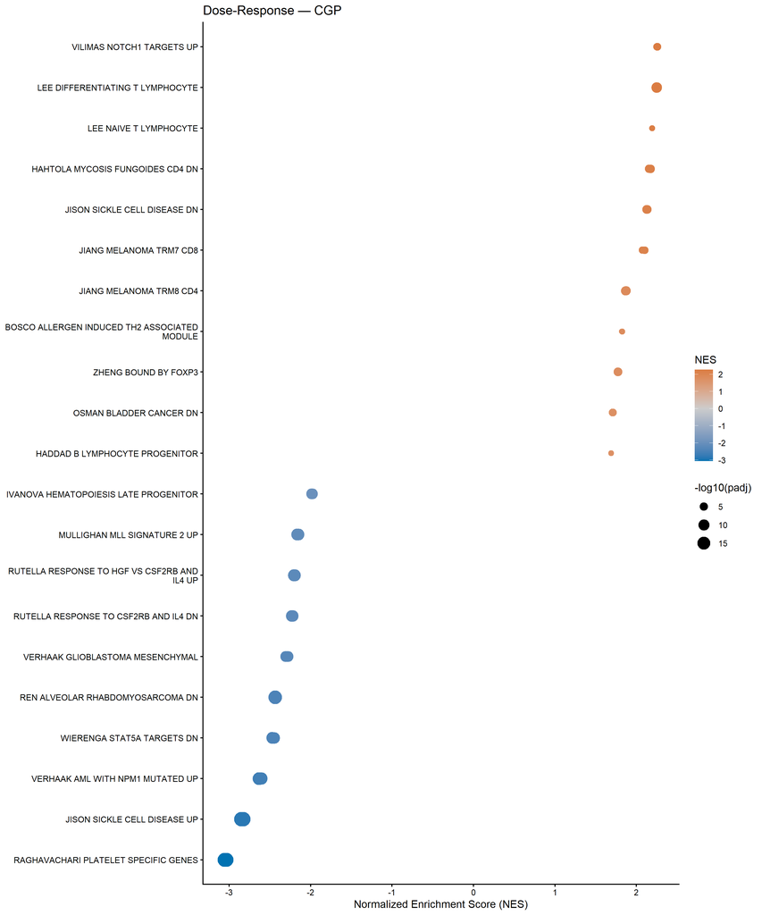

```
## Saved: dose_gsea_cgp.(png|pdf)  [10x12 in]
```

## 9.4 Dose publication dotplot

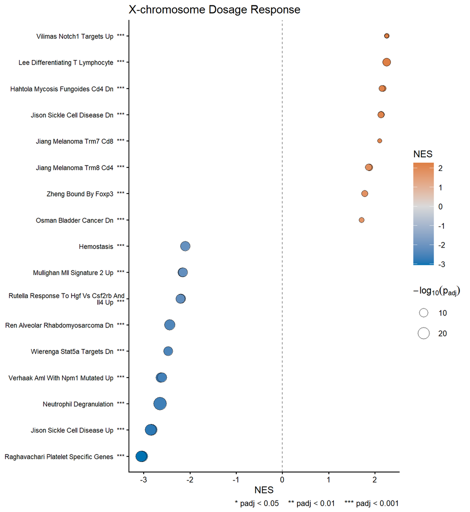

```
## Saved: dose_gsea_publication.(png|pdf)  [5.5x6 in]
```

## 9.5 Dose-response top-3 enrichment curves

[figure not shown]

```
## Saved: dose_enrichment_top3.(png|pdf)  [14x4 in]
```

## 9.6 Dose-response PRC2 / H3K27me3

Dose-Response fGSEA: PRC2 Targets & H3K27me3

| pathway | NES | pval | padj | size |
| --- | --- | --- | --- | --- |
| BENPORATH_PRC2_TARGETS | -1.1427 | 0.1880 | 0.2244 | 198 |
| MIKKELSEN_MEF_HCP_WITH_H3K27ME3 | 1.1126 | 0.2244 | 0.2244 | 143 |

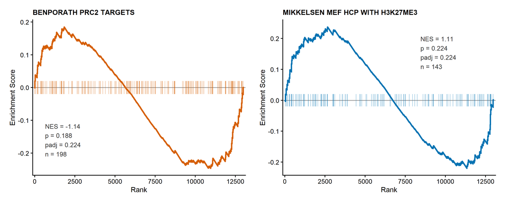

```
## Saved: dose_enrichment_PRC2_H3K27me3.(png|pdf)  [10x4 in]
```

# 10. TF Regulon Activity (DoRothEA)

## 10.1 Load DoRothEA regulons

```
## DoRothEA regulons (A/B/C): 246 TFs
```

## 10.2 MoR-weighted fgsea per TF

```
## Significant TFs (padj < 0.05): 9
```

## 10.3 Top TF tables

```
##
## === Top 15 Activated TFs (NES > 0) ===
```

| pathway | NES | padj | size |
| --- | --- | --- | --- |
| SPI1 | 2.099 | 0.000 | 90 |
| SOX2 | 1.842 | 0.001 | 165 |
| ELF3 | 2.124 | 0.001 | 31 |
| STAT2 | 2.120 | 0.002 | 25 |
| ZNF263 | 1.581 | 0.007 | 243 |
| EHF | 1.890 | 0.038 | 10 |
| SP3 | 1.801 | 0.046 | 41 |

```
##
## === Top 15 Repressed TFs (NES < 0) ===
```

| pathway | NES | padj | size |
| --- | --- | --- | --- |
| PRDM14 | -1.898 | 0.001 | 119 |
| E2F4 | -1.535 | 0.024 | 213 |

## 10.4 TF activity volcano

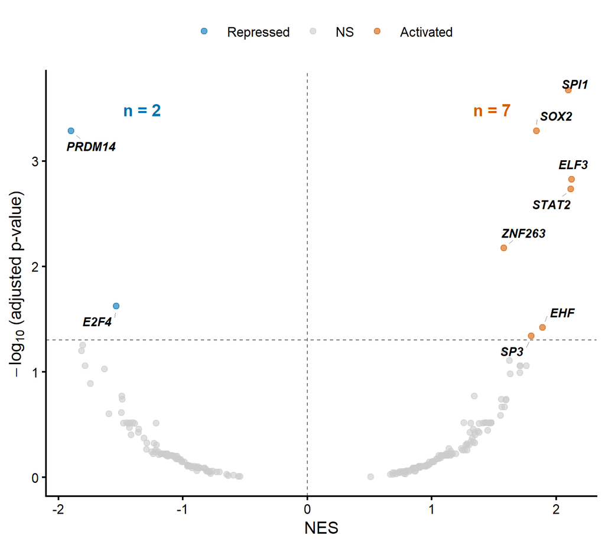

```
## Saved: tf_activity_volcano.(png|pdf)  [5x4.5 in]
```

## 10.5 TF activity dotplot

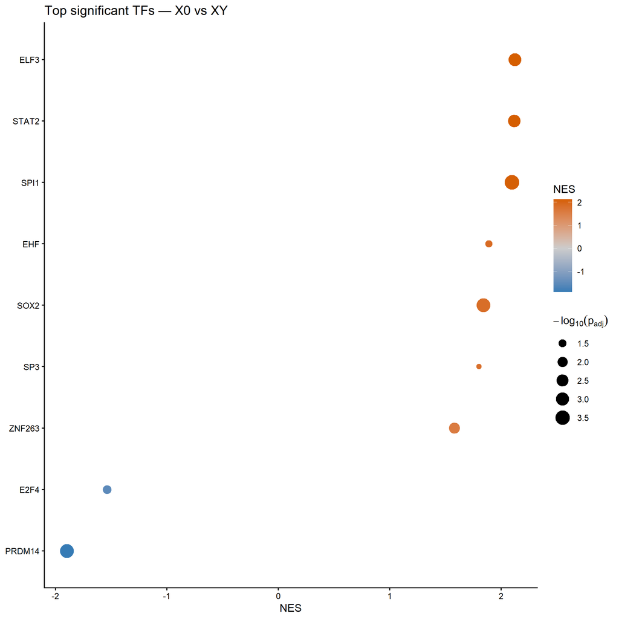

```
## Saved: tf_activity_dotplot.(png|pdf)  [8x8 in]
```

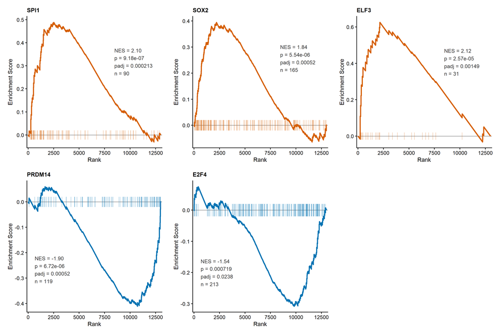

```
## Saved: tf_enrichment_top.(png|pdf)  [15x8 in]
```

## 10.7 TF regulon volcanos (per significant TF)

[figure not shown]

```
## Saved: tf_regulon_volcanos_combined.(png|pdf)  [16.5x15 in]
```

# 11. TF Activity (decoupleR / CollecTRI ULM)

## 11.1 Load CollecTRI network

```
## CollecTRI: 43159 interactions, 1186 TFs, 6686 targets
```

## 11.2 Sample-level ULM

Build a symbol-keyed log-CPM matrix (deduplicated) then run ULM with the CollecTRI network to get per-sample TF activity scores. PAR genes are stripped at the matrix-build step, matching the canonical pathway-flow filter policy.

```
## Sample-level ULM: 618 TFs x 54 samples
```

## 11.3 TF activity heatmap — all karyotypes

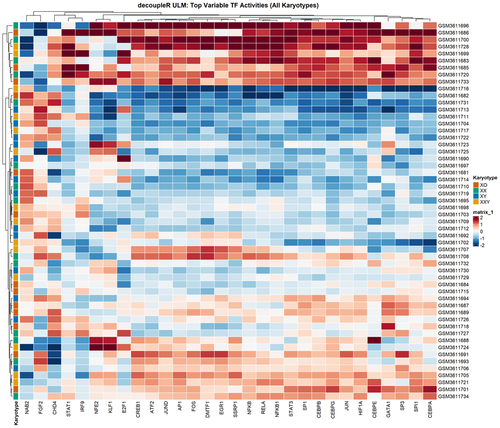

## 11.4 TF activity heatmap — X0 vs XY subset

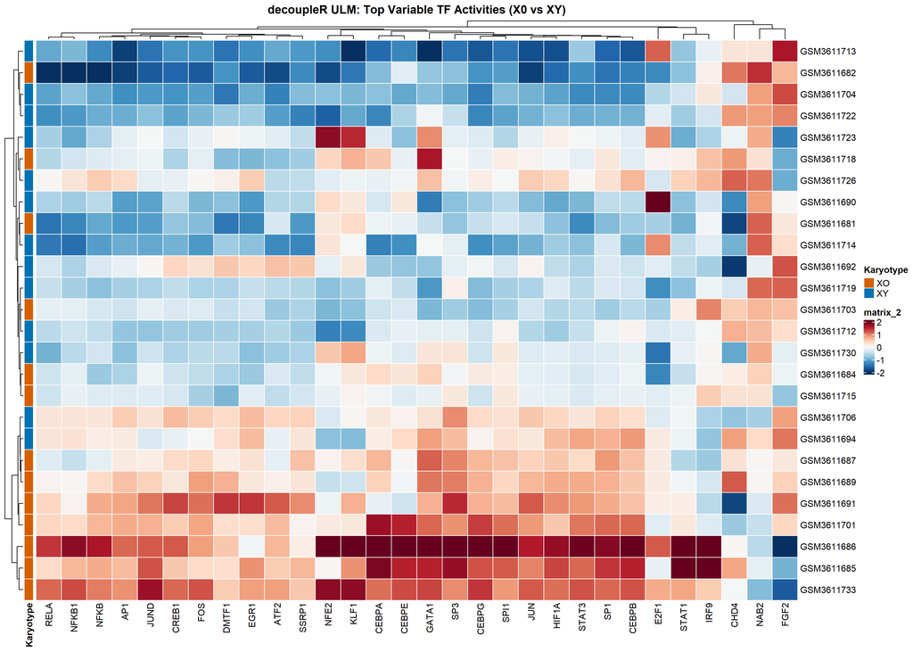

## 11.5 Contrast-level ULM (on limma t-statistics)

```
## Contrast-level ULM: 618 TFs scored
```

## 11.6 ULM TF activity bar plot

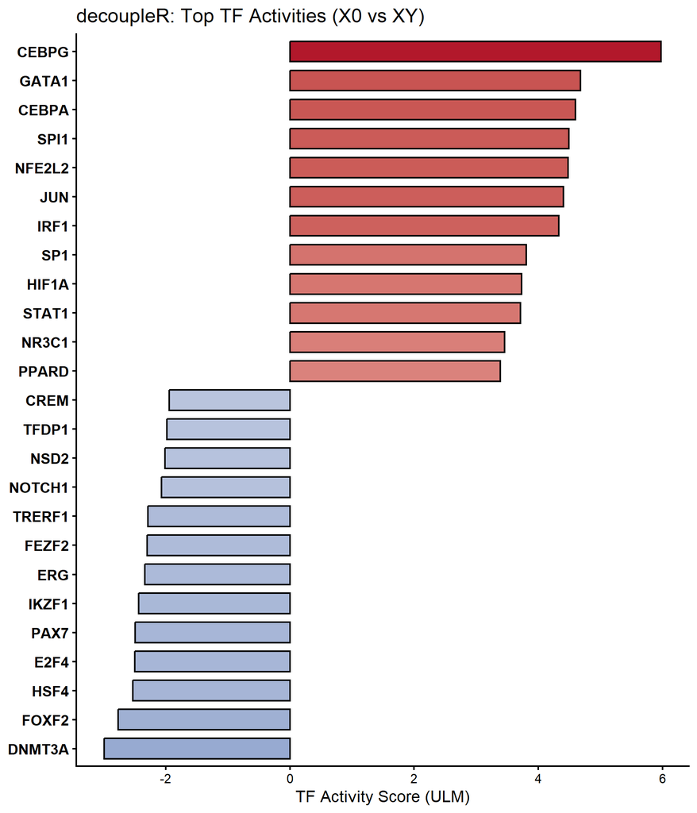

```
## Saved: decoupleR_TF_barplot.(png|pdf)  [6x7 in]
```

## 11.7 ULM volcano

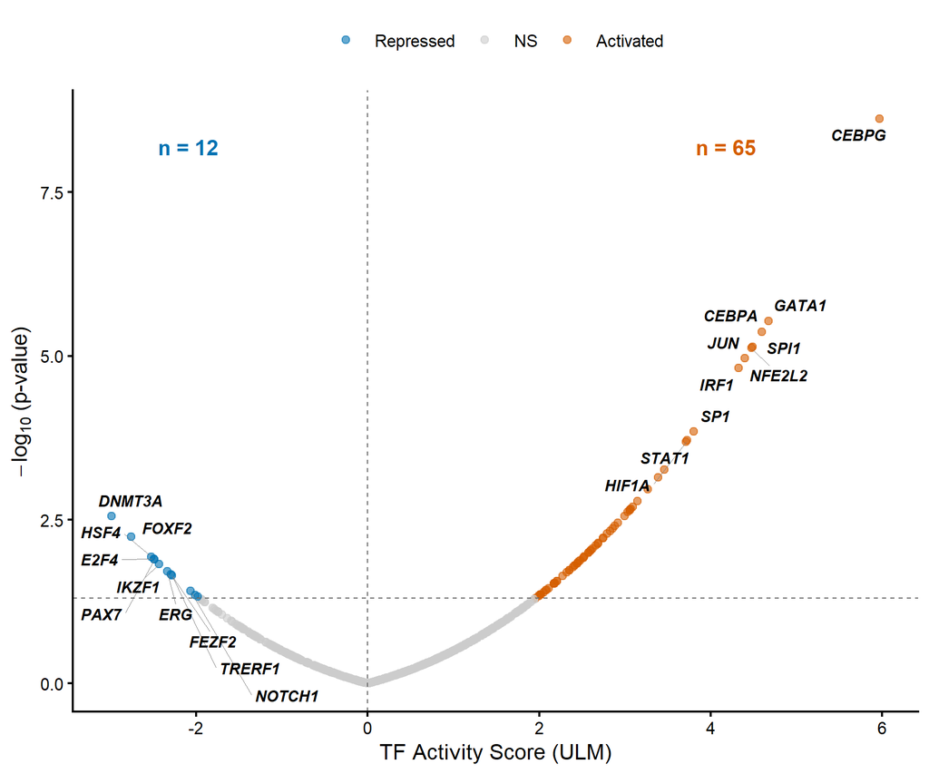

```
## Saved: decoupleR_TF_volcano.(png|pdf)  [6x5 in]
```

## 11.8 Target-gene scatter — top decoupleR TFs

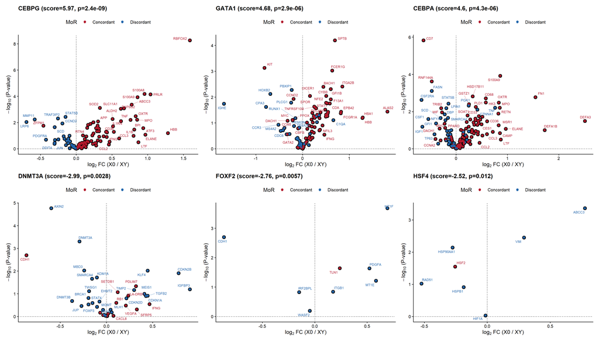

```
## Saved: decoupleR_target_scatter.(png|pdf)  [14x8 in]
```

## 11.9 Save decoupleR results

```
## decoupleR results saved to: A:/Dropbox/LOY_paralogs/projects/github/loy-synthetic-lethality/analysis/02_rnaseq/other/Turner/TF_analysis
```

# 12. Cross-method TF consistency

Turner GSE126712 doesn’t carry the matched paired-design + TCGA ARACNe regulons that the LNCaP / A549 / HT1080 base notebooks integrate with msVIPER, so the consistency axis here is a slimmer **two-method agreement** between DoRothEA-fgsea (§10) and decoupleR-ULM CollecTRI (§11). Both run on the same X0-vs-XY t-statistic ranking, with different regulons and different inference engines, so concordance flags TFs that robustly call X0-vs-XY independently of the regulon source.

## 12.1 Aggregate TF results

TF result counts by source (X0 vs XY)

| source | tested | sig |
| --- | --- | --- |
| DoRothEA | 232 | 9 |
| decoupleR_CollecTRI | 618 | 77 |

## 12.2 Consistency heatmap (top robust TFs)

Heatmap NES of TFs significant in **both methods** (or with the highest mean |NES| if fewer than the panel limit are dual-significant).

```
## TFs significant in both methods: 5   shown in heatmap: 40
```

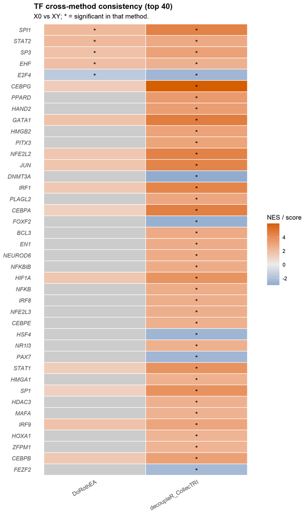

```
## Saved: tf_consistency_heatmap.(png|pdf)  [6x10 in]
```

## 12.3 Robust hits — TFs called by both methods

```
## Robust Turner TFs (DoRothEA + decoupleR_CollecTRI both sig): 5
```

Top 30 robust Turner TFs (both methods agree)

| TF | sig_count | NES_direction_mean | sig_sources |
| --- | --- | --- | --- |
| SPI1 | 2 | 3.29 | DoRothEA, decoupleR_CollecTRI |
| STAT2 | 2 | 2.46 | DoRothEA, decoupleR_CollecTRI |
| SP3 | 2 | 2.45 | DoRothEA, decoupleR_CollecTRI |
| EHF | 2 | 2.17 | DoRothEA, decoupleR_CollecTRI |
| E2F4 | 2 | -2.01 | DoRothEA, decoupleR_CollecTRI |

# 13. Cross-cohort overlap with LOY isogenic lines

The Turner X0-vs-XY signature describes whole-organism (lymphocyte) loss of one X chromosome from conception. The three LOY isogenic cell lines (A549, HT1080, LNCaP) describe targeted somatic loss of one Y chromosome in adult cell culture. Both share the structural feature “one fewer sex chromosome” but on a different axis (X vs Y; constitutive vs induced). Genes that respond concordantly across both contexts are candidates for a sex-chromosome-aneuploidy core signature; MYL9 in particular has come up repeatedly in the LOY analyses and is worth spotlighting here.

## 13.1 Load LOY cohort DE tables

```
## Loaded LOY DE tables: A549 = 14727 genes  |  HT1080 = 14381 genes  |  LNCaP = 13391 genes
```

## 13.2 Build unified per-gene table (Turner + 3 LOY cohorts)

```
## Unified table: 17856 unique genes across 4 cohorts
```

## 13.3 DEG overlap summary

```
## === DEG counts (FDR < 0.05, any direction) ===
```

```
##   Turner X0 vs XY            : 604
```

```
##   A549   LOY vs sgCTRL        : 0
```

```
##   HT1080 LOY vs sgCTRL        : 1116
```

```
##   LNCaP  LOY vs sgCTRL        : 193
```

```
##
## === Turner ∩ LOY overlap ===
```

```
##   Turner ∩ A549              : 0
```

```
##   Turner ∩ HT1080            : 61
```

```
##   Turner ∩ LNCaP             : 8
```

```
##   Turner ∩ (any LOY line)    : 66
```

```
##   Turner ∩ (>=2 LOY lines)   : 3
```

```
##   Turner ∩ all 3 LOY lines   : 0
```

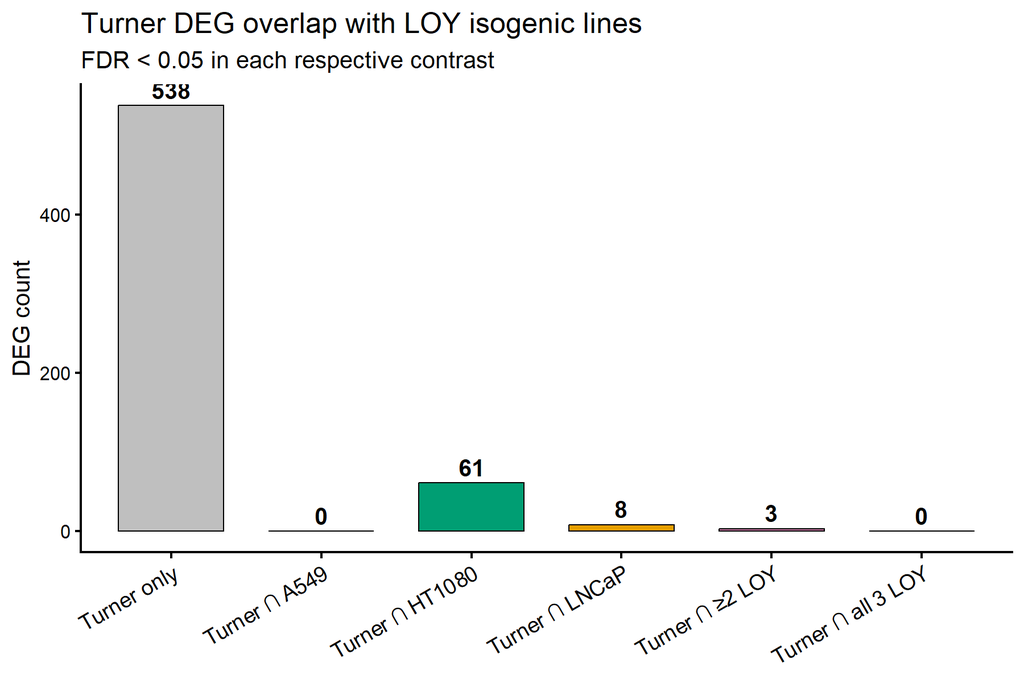

```
## Saved: overlap_DEG_counts.(png|pdf)  [6x4 in]
```

## 13.4 Concordance scatter — Turner logFC vs LOY logFC

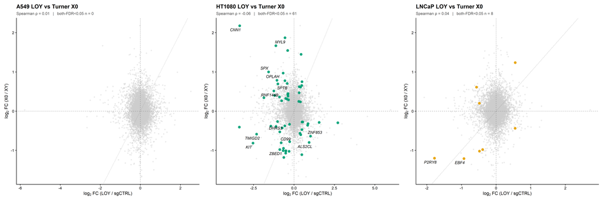

```
## Saved: overlap_concordance_scatter.(png|pdf)  [24x8 in]
```

## 13.5 Top shared DEGs across cohorts

Top 30 Turner DEGs also called in ≥1 LOY line (ranked by # lines + summed |logFC|)

| gene | Turner_lfc | A549_lfc | HT1080_lfc | LNCaP_lfc | n_loy_sig |
| --- | --- | --- | --- | --- | --- |
| ZBED1 | -0.98 | -0.60 | -0.87 | -0.39 | 2 |
| SLC25A6 | -1.02 | -0.60 | -0.50 | -0.48 | 2 |
| SNX21 | 0.61 | -0.08 | 0.40 | -0.56 | 2 |
| CNN1 | 2.18 | NA | -3.36 | NA | 1 |
| MYL9 | 1.67 | -1.88 | -1.12 | 0.03 | 1 |
| EBF4 | -1.21 | 0.78 | 1.47 | -0.93 | 1 |
| ZFP30 | -0.41 | -0.21 | -3.38 | 0.28 | 1 |
| KIT | -0.82 | NA | -2.53 | 0.23 | 1 |
| CARD11 | -0.30 | -0.02 | 2.71 | -0.48 | 1 |
| MAP1B | 1.87 | -0.51 | -0.55 | 0.16 | 1 |
| P2RY8 | -1.20 | NA | NA | -1.78 | 1 |
| TMIGD2 | -0.59 | NA | -2.31 | NA | 1 |
| SPX | 1.00 | 0.28 | -1.57 | NA | 1 |
| PFKFB2 | 0.34 | -0.51 | -1.86 | 0.09 | 1 |
| PLXNB3 | 1.45 | -0.50 | 0.44 | 0.33 | 1 |
| FN1 | 1.55 | 0.55 | -0.39 | 0.14 | 1 |
| GTPBP6 | -1.07 | -0.62 | -0.51 | -0.39 | 1 |
| IGFBP2 | 1.24 | -0.05 | -0.66 | 0.55 | 1 |
| DHRSX | -1.01 | -0.53 | -0.67 | -0.29 | 1 |
| SPTB | 0.69 | 0.75 | -0.99 | -0.04 | 1 |
| ASMTL | -0.95 | -0.46 | -0.65 | -0.25 | 1 |
| ZNF853 | -0.64 | 0.20 | 1.02 | -0.39 | 1 |
| IL3RA | -1.18 | -0.07 | -0.62 | -0.38 | 1 |
| CD99 | -0.81 | -0.39 | -0.79 | -0.26 | 1 |
| AKAP17A | -1.01 | -0.33 | -0.50 | -0.37 | 1 |
| TTYH2 | 0.36 | -0.83 | -0.90 | -0.08 | 1 |
| OPLAH | 0.79 | -0.12 | -1.05 | -0.21 | 1 |
| ABCC3 | 0.78 | 0.61 | -0.56 | -0.06 | 1 |
| PARP16 | -0.29 | -0.01 | 1.56 | 0.13 | 1 |
| HOXB-AS1 | -1.11 | 0.38 | 0.49 | NA | 1 |